Skip to main content

# Cocoa Farming and Access to Markets in Ghana

Published

November 23, 2026

Abstract

This study asks whether mapped cocoa in Ghana lies closer to major roads and urban centres than expected under a climate-and-elevation baseline. The analysis compares 57,131 cocoa-positive 1 km cells with 999 fixed-count simulated patterns under each of four baselines. Under the primary spatially cross-fitted model, the observed median distance was 1.30 km shorter for roads and 2.15 km shorter for urban centres than the simulated medians. Distance-binned and geographic intensity comparisons show where occupancy departs from that baseline. Uneven model performance across regions, uncertainty about source-raster coverage, and the use of straight-line distances limit the interpretation to provisional spatial association.

# Introduction

Cocoa is an important source of income for farming households in Ghana. Where farmers grow cocoa shapes how far beans must move to purchasing points, while the quality of rural roads affects how reliably those trips can be made. Ghana’s Auditor-General documented transport difficulties in cocoa-growing areas and reviewed the Cocoa Road Improvement Programme, launched in 2015 to improve connections between producing areas, purchasing centres and ports. The programme targeted cocoa-growing areas, illustrating that the location of cocoa production can also help determine where road investments go (Auditor-General of Ghana 2023).

Agricultural geography offers a competing explanation for apparent proximity to infrastructure. Cocoa occupies a geographically concentrated belt, and roads and settlements also vary across Ghana. A comparison with uniformly distributed locations would therefore combine the geography of temperature, rainfall and elevation with the geography of access. We ask whether mapped cocoa is systematically closer to major roads than expected under a baseline that allows cell occupancy to vary with those environmental conditions. We examine proximity to towns and cities as a secondary feature of the same landscape.

# Related research

## Roads and cocoa marketing

Ghana’s system of cocoa marketing distinguishes physical access from the price received by producers. Kolavalli and Vigneri (2017) describe a board-managed system that coordinates producer-price setting, quality control and export marketing. Even when a producer price is set centrally, farm-to-purchasing-point access can affect the time and transport needed to move beans. Urban centres may indicate broader access to population and services, but dedicated cocoa buying points may also be located in smaller communities. The nearest mapped town is therefore a secondary proxy for settlement proximity, and its relationship with farm-to-buyer travel is an empirical question.

Evidence from Ghana links transportation infrastructure to agricultural markets and the geography of production. In a comparison of two rural study areas, Acheampong et al. (2018) found that farmers in areas with improved roads used more inputs and showed greater market participation than farmers in areas with unpaved roads. Such comparisons show why road condition matters in addition to distance. The historical study by Jedwab and Moradi (2016) examines how colonial rail connections changed the geography of cocoa production and economic activity in Ghana. That research considers historical infrastructure investments. Our cross-sectional comparison addresses the present-day spatial association between mapped cocoa and the available mapped roads, with limited ability to establish when each feature appeared.

In February 2026, Ghana’s Ministry of Finance reported plans to use agricultural road financing in cocoa-growing areas (Ministry of Finance, Republic of Ghana 2026). That announcement establishes current policy relevance. The OpenStreetMap extract describes mapped infrastructure at a single date and does not track which projects were funded or completed.

## Mapping cocoa from satellite imagery

Kalischek et al. (2023) used satellite imagery and a high-resolution cocoa map to study cocoa expansion and forest loss in Ghana and Côte d’Ivoire. That map gives the present study a consistent spatial record of classified cocoa at a scale that can be compared with roads and settlements nationwide. Aggregation to a 1 km grid makes the environmental and accessibility layers comparable, although the unit represents presence somewhere in the cell and carries no direct information on the size of an individual farm, its production or its buyer.

This study adds a Ghana-wide comparison that holds the number of mapped cocoa-positive cells fixed and varies their locations under a climate-and-elevation baseline. It evaluates a directional road-distance hypothesis and then examines the broader first-order pattern with both a distance profile and an area-based intensity surface. Together these comparisons show whether the median difference is concentrated in particular distance ranges and where the environmental baseline reproduces or misses the geography of mapped cocoa.

Our directional hypothesis is that cocoa-positive cells have a shorter median distance to a major road than patterns drawn under the environmental null. Under that null, the fixed number of occupied cells is distributed according to weights estimated from climate and elevation. Median distance to an urban centre is a secondary comparison. Both statistics examine first-order variation in occupancy across the study window.

# Data and methods

## Input layers and study window

The ETH Zurich binary cocoa map (Kalischek 2024) was overlaid with WorldClim 2.1 annual mean temperature, annual precipitation and SRTM-derived elevation (Fick and Hijmans 2017; WorldClim 2021), plus roads and settlements from the Geofabrik Ghana OpenStreetMap snapshot (Geofabrik 2026; OpenStreetMap contributors 2026). The working boundary is the Geofabrik OSM national administrative polygon. It is provisional, not an independently validated official boundary.

Table 1: Input layers used in the reported estimates.

| Layer used | Observation period or version | Role |
| --- | --- | --- |
| ETH Zurich cocoa extent | 2019–2021 Sentinel-2 imagery, dataset released in 2024 | Mapped cocoa occupancy |
| WorldClim 2.1 | 1970–2000 climate normals and SRTM-derived elevation | Environmental baseline |
| Geofabrik Ghana | November 9, 2026 OpenStreetMap snapshot | Major roads, urban centres and working boundary |

The analysis uses a 1 km grid in EPSG:2136 (Accra / Ghana National Grid; Gold Coast feet). The working national polygon, the cocoa raster coverage mask and complete environmental predictors define eligibility; cells beyond the cocoa raster extent are excluded. The source product uses a 0.65 threshold for cocoa classification. Its approximately 10 m values are aggregated to 1 km, and any positive aggregate marks that cell as occupied. WorldClim inputs are resampled from 2.5 arc-minutes by bilinear interpolation. The candidate grid contains 240,294 cells, including 57,131 mapped-positive cells (23.8%). The OSM boundary geometry measures 251,021.5 km². The cocoa raster bounding box intersects 99.94% of this polygon by area; approximately 143.3 km² lies outside the bounding box. The boundary area is a geometry-derived diagnostic, not an authoritative area statistic.

## Environmental baseline and simulations

For the primary environmental null, a binomial generalized additive model generated five-fold spatially cross-fitted scores from smooth terms for mean annual temperature, log-transformed annual precipitation and elevation. Each held-out fold was scored by a model trained on the other four. Whole spatial blocks were grouped into five folds; 20 km blocks are primary, with 40 km as a sensitivity. Road and town distances were excluded as predictors. Each of four nulls generated 999 fixed-count (57,131), no-replacement patterns: 20 km cross-fit, 40 km cross-fit, in-sample environmental GAM, and uniform sampling across eligible candidate cells. The analysis uses 6,229 OSM motorway, trunk, primary and secondary line features and 577 mapped city, town and national-capital points. The urban-centre points serve as a settlement proxy; these are not verified cocoa-buying markets.

The primary statistic is the median Euclidean distance to a major road; median distance to an urban-centre proxy is secondary. Lower-tail Monte Carlo p-values use `(1 + number of simulated statistics <= observed) / 1000`. An exploratory functional diagnostic compares the observed positive-cell share with simulated shares across fixed distance bands (0–5, 5–10, 10–20, 20–50 and over 50 km). Its intervals are pointwise, not simultaneous.

## First-order spatial intensity comparison

First-order intensity describes how the expected number of occupied cells per unit area varies with location. For the road profile, the locations are grouped by distance to the nearest major road. Within each band, the estimated intensity is the number of cocoa-positive cells divided by the area of eligible 1 km cells in that band. This adjustment matters because distance bands differ substantially in available area. Each simulated pattern is evaluated with the same distance bands and denominator. The urban-centre profile applies the same calculation to a separate distance surface. This compares occupancy along an accessibility gradient without using distances between cocoa locations.

We also estimate a conventional area-based quadrat intensity surface over a fixed 25 km grid aligned to the Ghana National Grid. Each eligible 1 km cell contributes one square kilometre of grid support to the quadrat containing its centre. Intensity is the positive-cell count divided by this eligible grid area, including at the national edge. The same estimator is applied to each of the 999 primary environmental simulations. We map the observed estimate, the simulated median estimate, and where the observed estimate lies outside the 2.5th to 97.5th percentile interval for that quadrat. The 25 km scale summarizes broad geographic departures while retaining more spatial detail than the distance profiles. Both sets of intervals are pointwise. Their visual comparisons are exploratory, and the directional median-distance statistic remains the primary Monte Carlo test.

# Exploratory spatial analysis

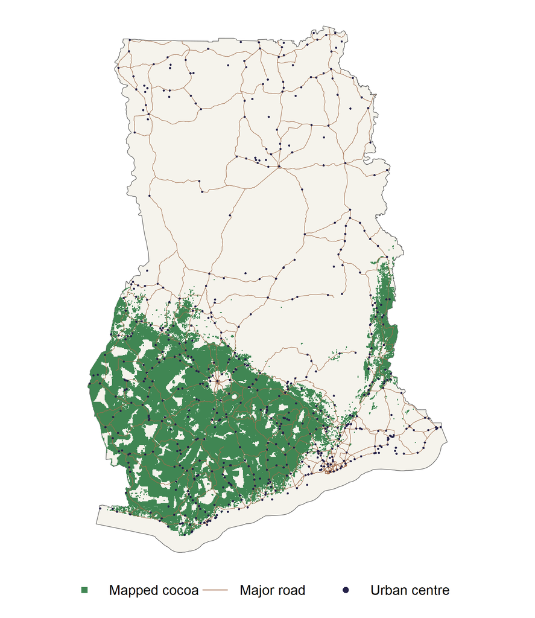

Figure 1: Mapped cocoa, major roads and urban centres in Ghana. Green squares represent cocoa-positive 1 km cells, brown lines show major roads, and purple points show cities, towns and national capitals. Cocoa data are from ETH Zurich. Road, settlement and boundary data are from OpenStreetMap contributors via Geofabrik.

Figure 1 shows a broad concentration in southern and southwestern Ghana and a narrower belt in the east. Roads and urban centres are visible within and beyond these concentrations. The overlap motivates a comparison with patterns that give greater weight to suitable climate and elevation.

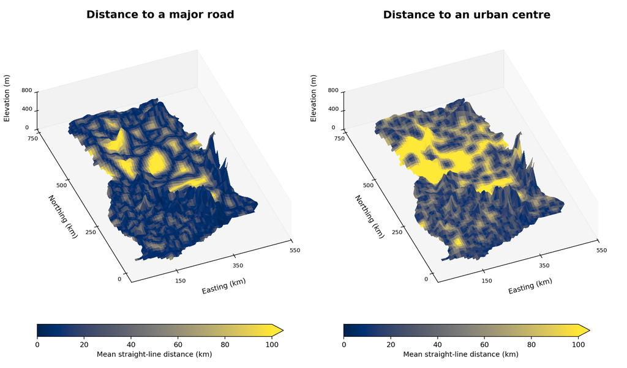

Figure 2: Terrain views of mean straight-line distance to the nearest major road (left) and mapped urban centre (right). Both panels use the same kilometre scale. Yellow includes distances of 100 km and above. Distances are averaged across eligible cells in each 8 km display bin. Elevation is vertically exaggerated.

Figure 2 shows the corridors of shorter distance around major roads and the wider pockets of remoteness between mapped towns and cities. These are two distance measures computed for every eligible cell. The tests below compare where observed and simulated cocoa patterns fall on those measures.

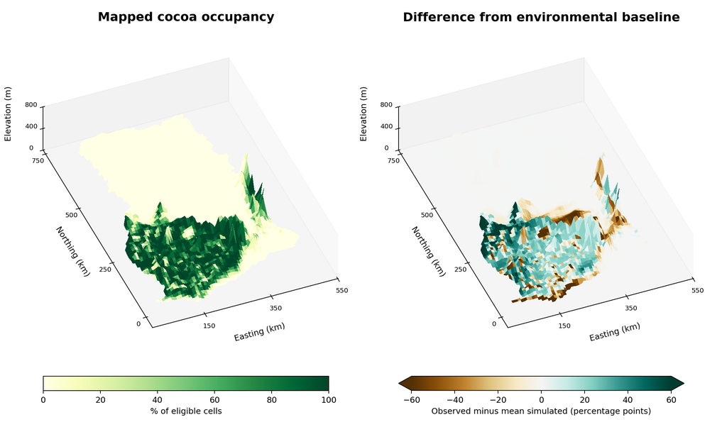

Figure 3: Ghana in two oblique terrain views. Green shows observed cocoa occupancy (left). Teal and brown show where occupancy is above and below simulated mean occupancy under the primary environmental baseline (right). Colour and SRTM-derived elevation are averaged over the same eligible 1 km cells within each 8 km display bin. Elevation is vertically exaggerated.

Figure 3 places the southern and eastern concentrations in their topographic context. Adjacent areas at similar elevations can have departures of opposite signs, particularly across the southern belt. The discrepancy panel describes the full temperature, precipitation and elevation baseline. The road-distance tests below evaluate the accessibility hypothesis directly.

# Hypothesis tests and results

## Median proximity and distance-binned intensity

The observed median distance is 11.96 km to a major road and 26.43 km to an urban-centre proxy. Across the 20 km cross-fitted environmental simulations, median road distance is 13.25 km (95% simulation interval 13.16–13.34 km; corrected lower-tail p = 0.001); median town/city distance is 28.58 km (28.46–28.70 km; p = 0.001). Under 40 km cross-fitting, the corresponding medians are 13.15 km (13.06–13.23 km) and 28.39 km (28.28–28.50 km), both p = 0.001. The in-sample environmental and uniform sensitivities also yield longer simulated medians than observed; exact values are in `ghana_simulation_summary.csv`.

| Null model | Statistic | Observed (km) | Simulated median (95% interval, km) | Observed / simulated | Lower-tail p |
| --- | --- | --- | --- | --- | --- |
| 20 km cross-fit | Major road | 11.96 | 13.25 (13.16–13.34) | 0.90 | 0.001 |
| 20 km cross-fit | Town/city | 26.43 | 28.58 (28.46–28.70) | 0.92 | 0.001 |
| 40 km cross-fit | Major road | 11.96 | 13.15 (13.06–13.23) | 0.91 | 0.001 |
| 40 km cross-fit | Town/city | 26.43 | 28.39 (28.28–28.50) | 0.93 | 0.001 |
| In-sample environmental | Major road | 11.96 | 13.00 (12.92–13.09) | 0.92 | 0.001 |
| In-sample environmental | Town/city | 26.43 | 28.24 (28.13–28.36) | 0.94 | 0.001 |
| Uniform region | Major road | 11.96 | 19.19 (19.00–19.38) | 0.62 | 0.001 |
| Uniform region | Town/city | 26.43 | 39.64 (39.37–39.93) | 0.67 | 0.001 |

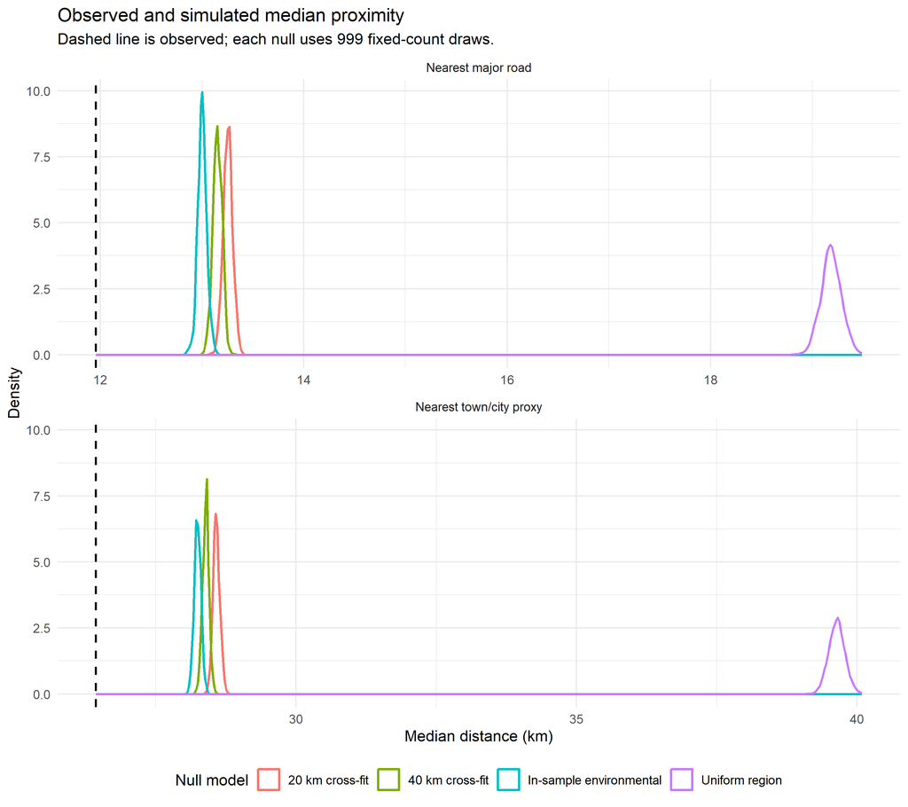

Figure 4: Observed and simulated median proximity under four fixed-count nulls. Dashed lines show observed medians.

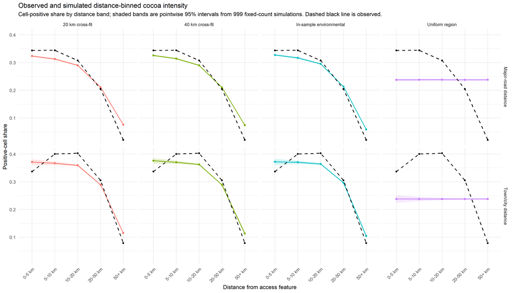

Figure 5: Observed and simulated cocoa-positive cell shares across fixed distance bands; shaded regions are pointwise 95% simulation intervals.

In the first column of Figure 5, observed positive-cell shares exceed the 20 km cross-fit simulation envelope in the 0–20 km bands and fall below it in the more distant bands. For the town/city proxy, observed shares are lower in the 0–5 km band, higher in the 5–50 km bands, and lower beyond 50 km, consistent with a shift from the most distant cells toward intermediate distances rather than a uniform increase at every distance. These pointwise band comparisons are exploratory and not a simultaneous test. The median-distance result is the pre-specified directional test. Its minimum p-value of 0.001 is the resolution of 999 draws, not evidence that the probability is zero. All results remain conditional on the cocoa map, eligible cells, boundary and environmental model.

## Whole road-distance profile

An exploratory whole-profile check compares all five road-distance bands at once. For each band, we centre and scale the occupied-cell shares across the observed pattern and all 999 draws together. We then take each pattern’s largest absolute standardized departure across the five bands. Applying the same calculation to every pattern preserves comparability and accounts for dependence among bands through the joint simulated profiles. The observed score was 27.93, compared with a maximum of 3.28 among the 999 simulated profiles (Monte Carlo rank p = 0.001). This post hoc result checks the fit of the road-distance profile under the same fitted baseline as the median test. Both comparisons share the environmental model’s geographic limitations.

## Geographic intensity

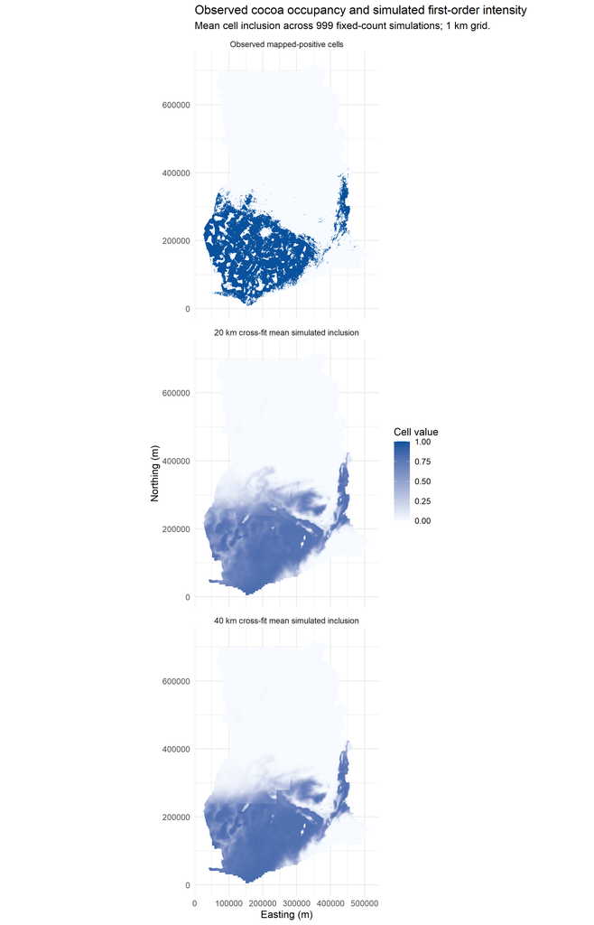

Figure 6: Observed mapped cocoa occupancy and mean cell inclusion under the 20 km and 40 km cross-fitted environmental nulls.

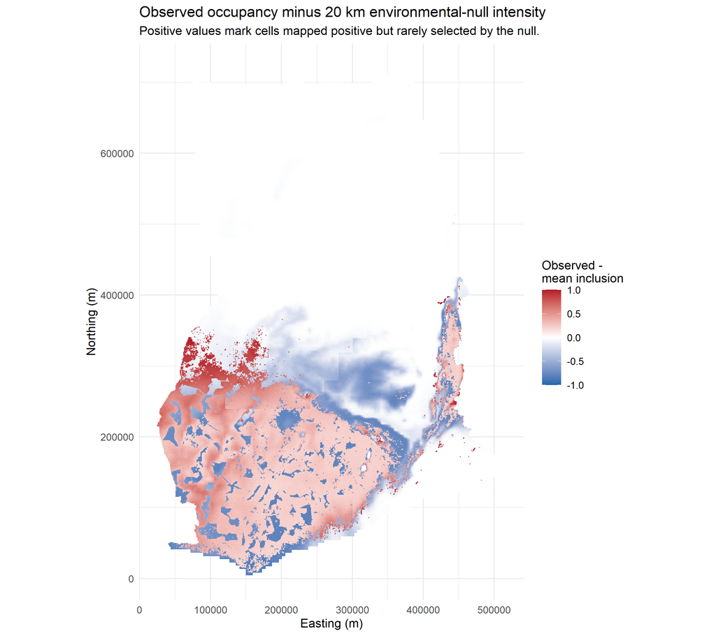

Figure 7: Observed cell occupancy minus mean simulated inclusion under the primary 20 km environmental null.

The 1 km maps show observed presence alongside mean simulated selection. Their cell-level residuals reveal differences within the broadly reproduced southern and eastern concentrations. The quadrat analysis below summarizes those differences across larger geographic units.

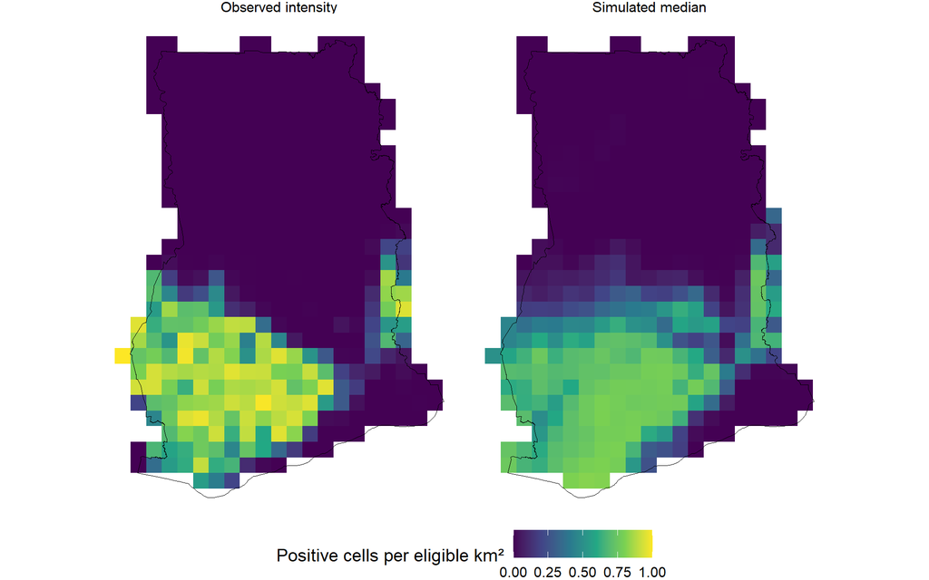

Figure 8: Observed and simulated median intensity on the same 25 km quadrats. The colour scale shows positive cells per eligible square kilometre under the primary 20 km cross-fitted environmental baseline.

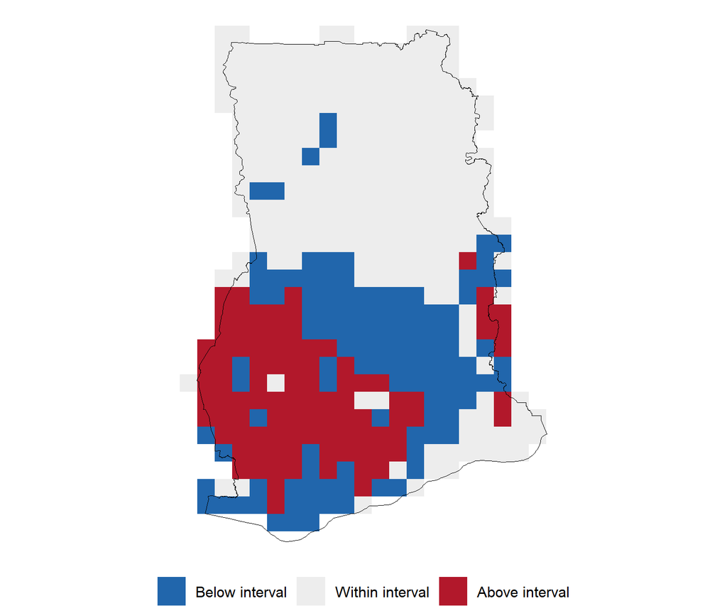

Figure 9: Quadrats where observed intensity falls below, within or above the pointwise 95% Monte Carlo interval from 999 primary environmental simulations. The thin line shows the working Ghana boundary.

The two surfaces in Figure 8 show high occupancy across much of southern Ghana and a narrower eastern concentration. Figure 9 shows where those broad similarities conceal local underprediction and overprediction. Across 440 quadrats with eligible cells, 97 observed intensities were above their pointwise intervals, 112 were below, and 231 fell within the intervals. This spread indicates substantial local mismatch despite the broad agreement. In 29 quadrats, fewer than 100 of the possible 625 square kilometres were eligible, so those estimates reflect relatively small areas. The number of departures is descriptive because the intervals cover one location at a time. Spatial departures could reflect missing environmental or land-use variables, classification error, or limitations of the fitted environmental model.

# Discussion

## Environmental model validity

The pooled out-of-fold AUCs are 0.934 (20 km) and 0.934 (40 km), while mean AUC across folds with both classes is 0.815 and 0.819, respectively. In both block-size designs, one held-out fold has no positive cells, so its AUC is undefined; the remaining fold AUC ranges are 0.463–0.976 and 0.458–0.987. Pooled scores combine predictions from different fold-specific fits and should not be read as a stable measure of national predictive performance. The strong between-fold variation and near-separation in some folds make the environmental scores an uncertain null model, despite finite simulated weights.

In the primary 20 km design, the weakest evaluable fold contains 37,453 of the 57,131 mapped cocoa-positive cells (65.6%). It has AUC 0.463 and a Brier score of 0.222, compared with a pooled Brier score of 0.089. The Brier score is the mean squared error of predicted probabilities, with lower values indicating smaller errors. The 42,313-cell fold with no mapped positives contributes many easy negatives to the pooled ranking. As a result, the pooled AUC can capture broad separation between regions even when the model ranks locations poorly within the main cocoa-growing area. An absence-only fold still informs the assessment of false positives there.

The similar distance results under 20 km and 40 km blocks establish sensitivity to those two choices. Their fold diagnostics show that both designs face the same geographic imbalance. The simulation intervals condition on the resulting weights, so they can be narrow even when the weights themselves are uncertain. A useful follow-up would compare geographically coherent, buffered folds with more balanced positive counts, inspect calibration in the cocoa belt separately, and rerun the simulations across credible alternative environmental fits.

## Limitations

- The project owner instructed that ETH raster NaN be interpreted as no cocoa only within the raster footprint. ETH metadata labels NaN as nodata and does not resolve its meaning; this remains an assumption that may misclassify unknown cells.
- The source raster footprint is not identical to Ghana’s boundary, and the area calculation relies on a provisional OSM polygon. Obtain an independently validated boundary and verify the source coverage before making definitive national claims.
- No independent land-cover/land-use mask excludes water, settlements or other unsuitable areas. A uniform-region comparison is a sensitivity, not a valid environmental control.
- The ETH map represents mapped cocoa rather than a farm census. Detection or classification errors can affect both the outcome and the learned environmental weights.
- WorldClim climate normals are for 1970–2000 and coarser than the 1 km analysis grid. OSM roads are a later snapshot; OSM places are incomplete urban-centre proxies, not purchasing markets.
- Fold allocation is geographically imbalanced, including one held-out fold without positive cells at each block size. The GAM also produced warnings about fitted probabilities near zero or one. Re-design cross-validation and assess model-fitting uncertainty before relying on the environmental null.
- Distances are Euclidean proximity, not network travel time. No causal inference or second-order clustering analysis is performed.

# Conclusion and roadmap

Mapped cocoa cells were a median 1.30 km closer to major roads than predicted by the primary climate-and-elevation baseline. The direction persists across the three environmental baselines, and the national maps show that substantial local differences remain even where they reproduce the broad cocoa belt. The median distance and intensity comparisons support a provisional first-order association between mapped cocoa and road proximity.

1. Verify the original raster’s coverage and the working boundary. Use the Ghanaian CERSGIS 2024–2025 reference polygons to check recent cocoa mapping agreement in sampled areas, accounting for the time gap (Centre for Remote Sensing and Geographic Information Services 2025).
2. Test whether the road-distance finding survives replacing the original map with the Forest Data Partnership’s 2026a cocoa product. Its 2020 and 2024 layers would allow a comparison across mapping products and years with an explicit threshold sensitivity check (Forest Data Partnership 2026). Reassess calibration with alternative spatial folds and a vetted land-cover mask.
3. Obtain verified cocoa purchasing locations and historical road-network data to compare network travel times using dates closer to the cocoa observations.

# Code and reproducibility

The [repository instructions](https://github.com/LuisaStu/GIS_Cocoa#reproduce-the-analysis) document input versions, checksums and the dated road extract. After acquiring the inputs and restoring the R environment, run these commands from the repository root. The terrain script uses NumPy and Matplotlib.

```bash
Rscript R/12_ghana_wide_null_model.R
Rscript R/13_ghana_wide_simulations.R
Rscript R/14_ghana_wide_reporting.R
Rscript --vanilla R/15_ghana_road_profile_check.R
python manuscript/terrain_maps.py
```

Inspect the [simulation code](https://github.com/LuisaStu/GIS_Cocoa/blob/main/R/13_ghana_wide_simulations.R) for the fixed-count draws and the [terrain code](https://github.com/LuisaStu/GIS_Cocoa/blob/main/manuscript/terrain_maps.py) for the display aggregation and perspective.

# References

Acheampong, Emmanuel Opoku, Jeffrey Sayer, and Colin J. Macgregor. 2018. “Road Improvement Enhances Smallholder Productivity and Reduces Forest Encroachment in Ghana.” *Environmental Science & Policy* 85: 64–71. https://doi.org/10.1016/j.envsci.2018.04.001.

Auditor-General of Ghana. 2023. *Performance Audit Report of the Auditor-General on the Construction of Cocoa Roads*. Ghana Audit Service. https://audit.gov.gh/files/audit_reports/Performance_Audit_Report_of_the_Auditor-General_on_the_construction_of_Cocoa_Roads.pdf.

Centre for Remote Sensing and Geographic Information Services. 2025. “Reference Dataset for Land Use Change Mapping in Ghana’s Cocoa Landscape (2024–2025).” Version 2.0. Zenodo. https://doi.org/10.5281/zenodo.16579443.

Fick, Stephen E., and Robert J. Hijmans. 2017. “WorldClim 2: New 1-Km Spatial Resolution Climate Surfaces for Global Land Areas.” *International Journal of Climatology* 37 (12): 4302–15. https://doi.org/10.1002/joc.5086.

Forest Data Partnership. 2026. “Cocoa Probability Model 2026a.” Google Earth Engine Data Catalog. https://developers.google.com/earth-engine/datasets/catalog/projects_forestdatapartnership_assets_cocoa_model_2026a.

Geofabrik. 2026. *Ghana OpenStreetMap Extracts*. https://download.geofabrik.de/africa/ghana.html.

Jedwab, Remi, and Alexander Moradi. 2016. “The Permanent Effects of Transportation Revolutions in Poor Countries: Evidence from Africa.” *Review of Economics and Statistics* 98 (2): 268–84. https://doi.org/10.1162/REST_a_00540.

Kalischek, Nikolai. 2024. “Map Data for ‘Cocoa Plantations Are Associated with Deforestation in Côte d’ivoire and Ghana’: Côte d’ivoire and Ghana Cocoa Extent Derived from Sentinel-2.” ETH Zurich. https://doi.org/10.3929/ethz-b-000654400.

Kalischek, Nikolai, Nico Lang, Cécile Renier, Rodrigo Caye Daudt, et al. 2023. “Cocoa Plantations Are Associated with Deforestation in Côte d’ivoire and Ghana.” *Nature Food* 4 (5): 384–93. https://doi.org/10.1038/s43016-023-00751-8.

Kolavalli, Shashidhara, and Marcella Vigneri. 2017. *The Cocoa Coast: The Board-Managed Cocoa Sector in Ghana*. International Food Policy Research Institute. https://doi.org/10.2499/9780896292703.

Ministry of Finance, Republic of Ghana. 2026. *Cocoa Sector Reforms for Financial Viability and Long-Term Sustainability*. https://www.mofep.gov.gh/sites/default/files/news/Press-Briefing-on-Cocoa.pdf.

OpenStreetMap contributors. 2026. *OpenStreetMap Copyright and License*. https://www.openstreetmap.org/copyright.

WorldClim. 2021. *WorldClim Version 2.1*. https://www.worldclim.org/data/worldclim21.html.